# Assignment 01 - Exploratory Data Analysis

```r
library(data.table)
library(leaflet)
library(tidyverse)
library(lubridate)
```

- Download process was done without R and thus is not shown here.

```r
epa2004 <- data.table(read.csv("epa2004.csv"))
epa2019 <- data.table(read.csv("epa2019.csv"))

head(epa2004)
```

```
##          Date Source  Site.ID POC Daily.Mean.PM2.5.Concentration    UNITS
## 1: 01/01/2004    AQS 60010007   1                            8.9 ug/m3 LC
## 2: 01/02/2004    AQS 60010007   1                           12.2 ug/m3 LC
## 3: 01/03/2004    AQS 60010007   1                           16.5 ug/m3 LC
## 4: 01/04/2004    AQS 60010007   1                           19.5 ug/m3 LC
## 5: 01/05/2004    AQS 60010007   1                           11.5 ug/m3 LC
## 6: 01/06/2004    AQS 60010007   1                           32.5 ug/m3 LC
##    DAILY_AQI_VALUE Site.Name DAILY_OBS_COUNT PERCENT_COMPLETE
## 1:              37 Livermore               1              100
## 2:              51 Livermore               1              100
## 3:              60 Livermore               1              100
## 4:              67 Livermore               1              100
## 5:              48 Livermore               1              100
## 6:              94 Livermore               1              100
##    AQS_PARAMETER_CODE                     AQS_PARAMETER_DESC CBSA_CODE
```

[output cut: 20 more lines]

```r
head(epa2019)
```

```
##          Date Source  Site.ID POC Daily.Mean.PM2.5.Concentration    UNITS
## 1: 01/01/2019    AQS 60010007   3                            5.7 ug/m3 LC
## 2: 01/02/2019    AQS 60010007   3                           11.9 ug/m3 LC
## 3: 01/03/2019    AQS 60010007   3                           20.1 ug/m3 LC
## 4: 01/04/2019    AQS 60010007   3                           28.8 ug/m3 LC
## 5: 01/05/2019    AQS 60010007   3                           11.2 ug/m3 LC
## 6: 01/06/2019    AQS 60010007   3                            2.7 ug/m3 LC
##    DAILY_AQI_VALUE Site.Name DAILY_OBS_COUNT PERCENT_COMPLETE
## 1:              24 Livermore               1              100
## 2:              50 Livermore               1              100
## 3:              68 Livermore               1              100
## 4:              86 Livermore               1              100
## 5:              47 Livermore               1              100
## 6:              11 Livermore               1              100
##    AQS_PARAMETER_CODE       AQS_PARAMETER_DESC CBSA_CODE
```

[output cut: 20 more lines]

```r
tail(epa2004)
```

```
##          Date Source  Site.ID POC Daily.Mean.PM2.5.Concentration    UNITS
## 1: 12/14/2004    AQS 61131003   1                             11 ug/m3 LC
## 2: 12/17/2004    AQS 61131003   1                             16 ug/m3 LC
## 3: 12/20/2004    AQS 61131003   1                             17 ug/m3 LC
## 4: 12/23/2004    AQS 61131003   1                              9 ug/m3 LC
## 5: 12/26/2004    AQS 61131003   1                             24 ug/m3 LC
## 6: 12/29/2004    AQS 61131003   1                              9 ug/m3 LC
##    DAILY_AQI_VALUE            Site.Name DAILY_OBS_COUNT PERCENT_COMPLETE
## 1:              46 Woodland-Gibson Road               1              100
## 2:              59 Woodland-Gibson Road               1              100
## 3:              61 Woodland-Gibson Road               1              100
## 4:              38 Woodland-Gibson Road               1              100
## 5:              76 Woodland-Gibson Road               1              100
## 6:              38 Woodland-Gibson Road               1              100
##    AQS_PARAMETER_CODE       AQS_PARAMETER_DESC CBSA_CODE
```

[output cut: 20 more lines]

```r
tail(epa2019)
```

```
##          Date Source  Site.ID POC Daily.Mean.PM2.5.Concentration    UNITS
## 1: 11/11/2019    AQS 61131003   1                           13.5 ug/m3 LC
## 2: 11/17/2019    AQS 61131003   1                           18.1 ug/m3 LC
## 3: 11/29/2019    AQS 61131003   1                           12.5 ug/m3 LC
## 4: 12/17/2019    AQS 61131003   1                           23.8 ug/m3 LC
## 5: 12/23/2019    AQS 61131003   1                            1.0 ug/m3 LC
## 6: 12/29/2019    AQS 61131003   1                            9.1 ug/m3 LC
##    DAILY_AQI_VALUE            Site.Name DAILY_OBS_COUNT PERCENT_COMPLETE
## 1:              54 Woodland-Gibson Road               1              100
## 2:              64 Woodland-Gibson Road               1              100
## 3:              52 Woodland-Gibson Road               1              100
## 4:              76 Woodland-Gibson Road               1              100
## 5:               4 Woodland-Gibson Road               1              100
## 6:              38 Woodland-Gibson Road               1              100
##    AQS_PARAMETER_CODE       AQS_PARAMETER_DESC CBSA_CODE
```

[output cut: 20 more lines]

```r
str(epa2004)
```

```
## Classes 'data.table' and 'data.frame':   19233 obs. of  20 variables:
##  $ Date                          : chr  "01/01/2004" "01/02/2004" "01/03/2004" "01/04/2004" ...
##  $ Source                        : chr  "AQS" "AQS" "AQS" "AQS" ...
##  $ Site.ID                       : int  60010007 60010007 60010007 60010007 60010007 60010007 60010007 60010007 60010007 60010007 ...
##  $ POC                           : int  1 1 1 1 1 1 1 1 1 1 ...
##  $ Daily.Mean.PM2.5.Concentration: num  8.9 12.2 16.5 19.5 11.5 32.5 15.5 29.9 21 16.9 ...
##  $ UNITS                         : chr  "ug/m3 LC" "ug/m3 LC" "ug/m3 LC" "ug/m3 LC" ...
##  $ DAILY_AQI_VALUE               : int  37 51 60 67 48 94 58 88 70 61 ...
##  $ Site.Name                     : chr  "Livermore" "Livermore" "Livermore" "Livermore" ...
##  $ DAILY_OBS_COUNT               : int  1 1 1 1 1 1 1 1 1 1 ...
##  $ PERCENT_COMPLETE              : num  100 100 100 100 100 100 100 100 100 100 ...
##  $ AQS_PARAMETER_CODE            : int  88101 88502 88502 88502 88502 88502 88502 88502 88502 88502 ...
##  $ AQS_PARAMETER_DESC            : chr  "PM2.5 - Local Conditions" "Acceptable PM2.5 AQI & Speciation Mass" "Acceptable PM2.5 AQI & Speciation Mass" "Acceptable PM2.5 AQI & Speciation Mass" ...
##  $ CBSA_CODE                     : int  41860 41860 41860 41860 41860 41860 41860 41860 41860 41860 ...
##  $ CBSA_NAME                     : chr  "San Francisco-Oakland-Hayward, CA" "San Francisco-Oakland-Hayward, CA" "San Francisco-Oakland-Hayward, CA" "San Francisco-Oakland-Hayward, CA" ...
##  $ STATE_CODE                    : int  6 6 6 6 6 6 6 6 6 6 ...
##  $ STATE                         : chr  "California" "California" "California" "California" ...
##  $ COUNTY_CODE                   : int  1 1 1 1 1 1 1 1 1 1 ...
##  $ COUNTY                        : chr  "Alameda" "Alameda" "Alameda" "Alameda" ...
##  $ SITE_LATITUDE                 : num  37.7 37.7 37.7 37.7 37.7 ...
##  $ SITE_LONGITUDE                : num  -122 -122 -122 -122 -122 ...
##  - attr(*, ".internal.selfref")=<externalptr>
```

```r
str(epa2019)
```

```
## Classes 'data.table' and 'data.frame':   53328 obs. of  20 variables:
##  $ Date                          : chr  "01/01/2019" "01/02/2019" "01/03/2019" "01/04/2019" ...
##  $ Source                        : chr  "AQS" "AQS" "AQS" "AQS" ...
##  $ Site.ID                       : int  60010007 60010007 60010007 60010007 60010007 60010007 60010007 60010007 60010007 60010007 ...
##  $ POC                           : int  3 3 3 3 3 3 3 3 3 3 ...
##  $ Daily.Mean.PM2.5.Concentration: num  5.7 11.9 20.1 28.8 11.2 2.7 2.8 7 3.1 7.1 ...
##  $ UNITS                         : chr  "ug/m3 LC" "ug/m3 LC" "ug/m3 LC" "ug/m3 LC" ...
##  $ DAILY_AQI_VALUE               : int  24 50 68 86 47 11 12 29 13 30 ...
##  $ Site.Name                     : chr  "Livermore" "Livermore" "Livermore" "Livermore" ...
##  $ DAILY_OBS_COUNT               : int  1 1 1 1 1 1 1 1 1 1 ...
##  $ PERCENT_COMPLETE              : num  100 100 100 100 100 100 100 100 100 100 ...
##  $ AQS_PARAMETER_CODE            : int  88101 88101 88101 88101 88101 88101 88101 88101 88101 88101 ...
##  $ AQS_PARAMETER_DESC            : chr  "PM2.5 - Local Conditions" "PM2.5 - Local Conditions" "PM2.5 - Local Conditions" "PM2.5 - Local Conditions" ...
##  $ CBSA_CODE                     : int  41860 41860 41860 41860 41860 41860 41860 41860 41860 41860 ...
##  $ CBSA_NAME                     : chr  "San Francisco-Oakland-Hayward, CA" "San Francisco-Oakland-Hayward, CA" "San Francisco-Oakland-Hayward, CA" "San Francisco-Oakland-Hayward, CA" ...
##  $ STATE_CODE                    : int  6 6 6 6 6 6 6 6 6 6 ...
##  $ STATE                         : chr  "California" "California" "California" "California" ...
##  $ COUNTY_CODE                   : int  1 1 1 1 1 1 1 1 1 1 ...
##  $ COUNTY                        : chr  "Alameda" "Alameda" "Alameda" "Alameda" ...
##  $ SITE_LATITUDE                 : num  37.7 37.7 37.7 37.7 37.7 ...
##  $ SITE_LONGITUDE                : num  -122 -122 -122 -122 -122 ...
##  - attr(*, ".internal.selfref")=<externalptr>
```

```r
summary(epa2004)
```

```
##      Date              Source             Site.ID              POC
##  Length:19233       Length:19233       Min.   :60010007   Min.   : 1.000
##  Class :character   Class :character   1st Qu.:60370002   1st Qu.: 1.000
##  Mode  :character   Mode  :character   Median :60658001   Median : 1.000
##                                        Mean   :60588026   Mean   : 1.816
##                                        3rd Qu.:60750006   3rd Qu.: 2.000
##                                        Max.   :61131003   Max.   :12.000
##
##  Daily.Mean.PM2.5.Concentration    UNITS           DAILY_AQI_VALUE
##  Min.   : -0.10                 Length:19233       Min.   :  0.00
##  1st Qu.:  6.00                 Class :character   1st Qu.: 25.00
##  Median : 10.10                 Mode  :character   Median : 42.00
##  Mean   : 13.13                                    Mean   : 46.32
##  3rd Qu.: 16.30                                    3rd Qu.: 60.00
##  Max.   :251.00                                    Max.   :301.00
##
##   Site.Name         DAILY_OBS_COUNT PERCENT_COMPLETE AQS_PARAMETER_CODE
##  Length:19233       Min.   :1       Min.   :100      Min.   :88101
##  Class :character   1st Qu.:1       1st Qu.:100      1st Qu.:88101
##  Mode  :character   Median :1       Median :100      Median :88101
##                     Mean   :1       Mean   :100      Mean   :88267
##                     3rd Qu.:1       3rd Qu.:100      3rd Qu.:88502
##                     Max.   :1       Max.   :100      Max.   :88502
##
##  AQS_PARAMETER_DESC   CBSA_CODE      CBSA_NAME           STATE_CODE
##  Length:19233       Min.   :12540   Length:19233       Min.   :6
##  Class :character   1st Qu.:31080   Class :character   1st Qu.:6
##  Mode  :character   Median :40140   Mode  :character   Median :6
##                     Mean   :35328                      Mean   :6
##                     3rd Qu.:41860                      3rd Qu.:6
##                     Max.   :49700                      Max.   :6
##                     NA's   :1253
##     STATE            COUNTY_CODE        COUNTY          SITE_LATITUDE
##  Length:19233       Min.   :  1.00   Length:19233       Min.   :32.63
##  Class :character   1st Qu.: 37.00   Class :character   1st Qu.:34.07
##  Mode  :character   Median : 65.00   Mode  :character   Median :36.48
##                     Mean   : 58.63                      Mean   :36.23
##                     3rd Qu.: 75.00                      3rd Qu.:38.10
##                     Max.   :113.00                      Max.   :41.71
##
##  SITE_LONGITUDE
##  Min.   :-124.2
##  1st Qu.:-121.6
##  Median :-119.3
##  Mean   :-119.7
##  3rd Qu.:-117.9
##  Max.   :-115.5
##
```

```r
summary(epa2019)
```

```
##      Date              Source             Site.ID              POC
##  Length:53328       Length:53328       Min.   :60010007   Min.   : 1.000
##  Class :character   Class :character   1st Qu.:60310004   1st Qu.: 1.000
##  Mode  :character   Mode  :character   Median :60612003   Median : 3.000
##                                        Mean   :60565289   Mean   : 2.522
##                                        3rd Qu.:60771002   3rd Qu.: 3.000
##                                        Max.   :61131003   Max.   :21.000
##
##  Daily.Mean.PM2.5.Concentration    UNITS           DAILY_AQI_VALUE
##  Min.   : -2.200                Length:53328       Min.   :  0.0
##  1st Qu.:  4.000                Class :character   1st Qu.: 17.0
##  Median :  6.500                Mode  :character   Median : 27.0
##  Mean   :  7.744                                   Mean   : 30.6
##  3rd Qu.:  9.900                                   3rd Qu.: 41.0
##  Max.   :120.900                                   Max.   :185.0
##
##   Site.Name         DAILY_OBS_COUNT PERCENT_COMPLETE AQS_PARAMETER_CODE
##  Length:53328       Min.   :1       Min.   :100      Min.   :88101
##  Class :character   1st Qu.:1       1st Qu.:100      1st Qu.:88101
##  Mode  :character   Median :1       Median :100      Median :88101
##                     Mean   :1       Mean   :100      Mean   :88221
##                     3rd Qu.:1       3rd Qu.:100      3rd Qu.:88502
##                     Max.   :1       Max.   :100      Max.   :88502
##
##  AQS_PARAMETER_DESC   CBSA_CODE      CBSA_NAME           STATE_CODE
##  Length:53328       Min.   :12540   Length:53328       Min.   :6
##  Class :character   1st Qu.:31080   Class :character   1st Qu.:6
##  Mode  :character   Median :40140   Mode  :character   Median :6
##                     Mean   :35893                      Mean   :6
##                     3rd Qu.:41860                      3rd Qu.:6
##                     Max.   :49700                      Max.   :6
##                     NA's   :4157
##     STATE            COUNTY_CODE        COUNTY          SITE_LATITUDE
##  Length:53328       Min.   :  1.00   Length:53328       Min.   :32.58
##  Class :character   1st Qu.: 31.00   Class :character   1st Qu.:34.19
##  Mode  :character   Median : 61.00   Mode  :character   Median :36.63
##                     Mean   : 56.39                      Mean   :36.36
##                     3rd Qu.: 77.00                      3rd Qu.:37.97
##                     Max.   :113.00                      Max.   :41.76
##
##  SITE_LONGITUDE
##  Min.   :-124.2
##  1st Qu.:-121.6
##  Median :-119.8
##  Mean   :-119.8
##  3rd Qu.:-118.1
##  Max.   :-115.5
##
```

```r
summary(epa2004$SITE_LATITUDE)
```

```
##    Min. 1st Qu.  Median    Mean 3rd Qu.    Max.
##   32.63   34.07   36.48   36.23   38.10   41.71
```

```r
summary(epa2019$SITE_LATITUDE)
```

```
##    Min. 1st Qu.  Median    Mean 3rd Qu.    Max.
##   32.58   34.19   36.63   36.36   37.97   41.76
```

```r
summary(epa2004$SITE_LONGITUDE)
```

```
##    Min. 1st Qu.  Median    Mean 3rd Qu.    Max.
##  -124.2  -121.6  -119.3  -119.7  -117.9  -115.5
```

```r
summary(epa2019$SITE_LONGITUDE)
```

```
##    Min. 1st Qu.  Median    Mean 3rd Qu.    Max.
##  -124.2  -121.6  -119.8  -119.8  -118.1  -115.5
```

```r
summary(epa2004$DAILY_AQI_VALUE)
```

```
##    Min. 1st Qu.  Median    Mean 3rd Qu.    Max.
##    0.00   25.00   42.00   46.32   60.00  301.00
```

```r
summary(epa2019$DAILY_AQI_VALUE)
```

```
##    Min. 1st Qu.  Median    Mean 3rd Qu.    Max.
##     0.0    17.0    27.0    30.6    41.0   185.0
```

```r
summary(epa2004$Daily.Mean.PM2.5.Concentration)
```

```
##    Min. 1st Qu.  Median    Mean 3rd Qu.    Max.
##   -0.10    6.00   10.10   13.13   16.30  251.00
```

```r
summary(epa2019$Daily.Mean.PM2.5.Concentration)
```

```
##    Min. 1st Qu.  Median    Mean 3rd Qu.    Max.
##  -2.200   4.000   6.500   7.744   9.900 120.900
```

- According to the dimensions of two data sets, we have more air quality data in 2019 than in 2004; no obvious problem is observed for headers, footers, variable names and types of two data sets. The ranges of latitude, longitude and AQI also seems reasonable. Some negative reads are observed for PM2.5 concentration, which does not make sense and needs to be adjusted later.

```r
epa <- rbind(epa2004, epa2019)

epa$year <- year(mdy(epa$Date))

epa <- rename(epa, pm25 = Daily.Mean.PM2.5.Concentration, lat = SITE_LATITUDE, lon = SITE_LONGITUDE)
```

```r
leaflet() %>%
  addProviderTiles('OpenStreetMap') %>%
  addCircles(data = filter(epa, year == 2019), lat = ~lat, lng = ~lon, opacity = 1, fillOpacity = 1, radius = 50, color = "blue") %>%
  addCircles(data = filter(epa, year == 2004), lat = ~lat, lng = ~lon, opacity = 1, fillOpacity = 1, radius = 50, color = "red")
```

[interactive chart not shown]

- Many monitoring sites have been added during this 15 years, but no obvious trend is observed for spatial distribution of the monitoring sites.
- It is assumed here that the negative reads of PM2.5 concentration are implausible.

```r
dim(filter(epa, is.na(pm25)))[1]/dim(epa)[1]
```

```
## [1] 0
```

```r
dim(filter(epa, pm25 < 0))[1]/dim(epa)[1]
```

```
## [1] 0.004037982
```

```r
epa <- filter(epa, pm25 > 0)

summary(epa$pm25)
```

```
##    Min. 1st Qu.  Median    Mean 3rd Qu.    Max.
##   0.100   4.500   7.300   9.223  11.300 251.000
```

- No missing value are observed in PM2.5 concentration variable. Only about 0.4% of the values are implausible and are removed from the data set. Statistic summary shows that the distribution of this variable is highly skewed.

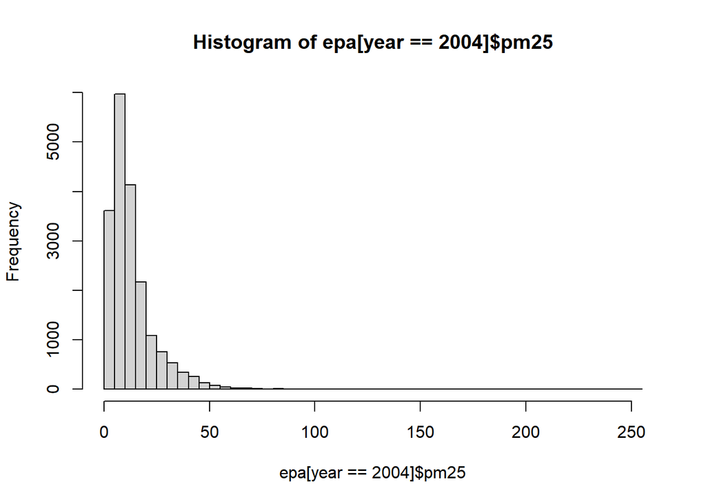

```r
hist(epa[year == 2004]$pm25, breaks=40)
```

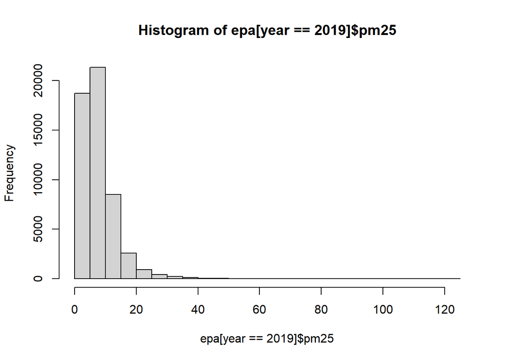

```r
hist(epa[year == 2019]$pm25, breaks=40)
```

```r
summary(epa[year == 2004]$pm25)
```

```
##    Min. 1st Qu.  Median    Mean 3rd Qu.    Max.
##    0.10    6.00   10.10   13.13   16.30  251.00
```

```r
summary(epa[year == 2019]$pm25)
```

```
##    Min. 1st Qu.  Median    Mean 3rd Qu.    Max.
##   0.100   4.100   6.600   7.803  10.000 120.900
```

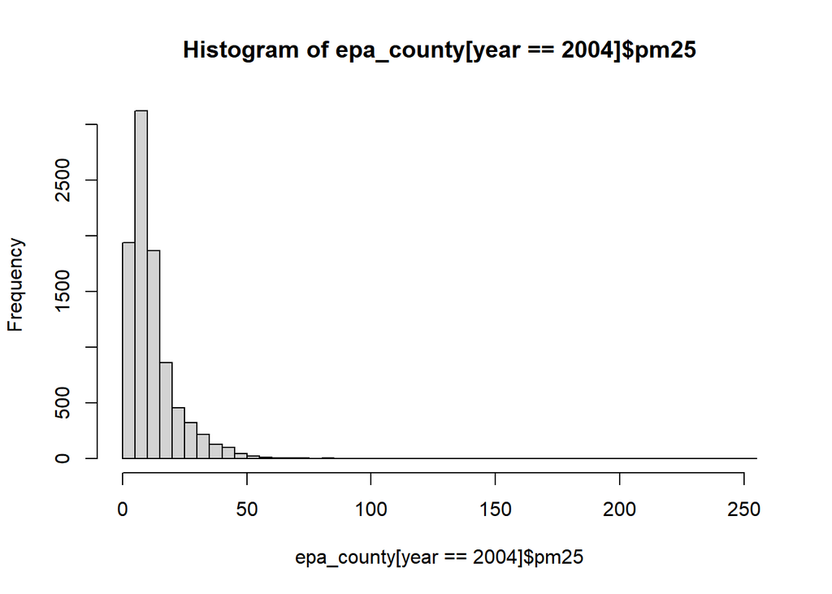

```r
epa_county <- epa[,.(pm25 = mean(pm25), lat = mean(lat), lon = mean(lon), year = mean(year)), by = c("COUNTY", "Date")]

hist(epa_county[year == 2004]$pm25, breaks=40)
```

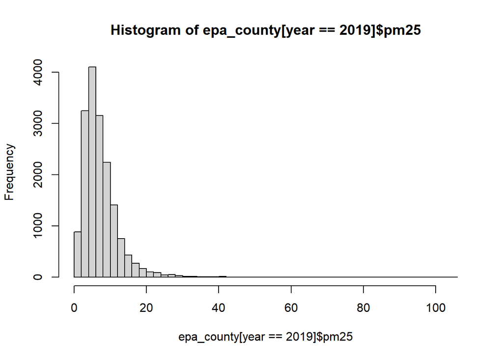

```r
hist(epa_county[year == 2019]$pm25, breaks=40)
```

```r
summary(epa_county[year == 2004]$pm25)
```

```
##    Min. 1st Qu.  Median    Mean 3rd Qu.    Max.
##    0.10    5.60    9.10   11.93   14.70  251.00
```

```r
summary(epa_county[year == 2019]$pm25)
```

```
##    Min. 1st Qu.  Median    Mean 3rd Qu.    Max.
##   0.100   4.100   6.200   7.313   9.200 104.500
```

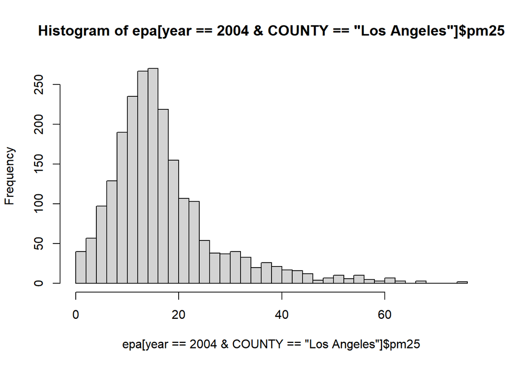

```r
hist(epa[year == 2004 & COUNTY == "Los Angeles"]$pm25, breaks=40)
```

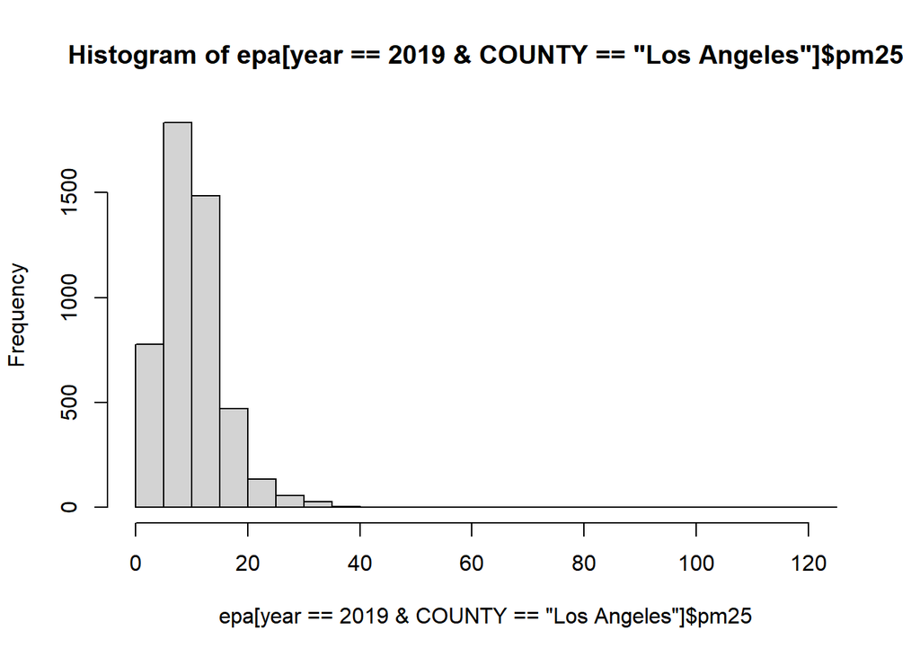

```r
hist(epa[year == 2019 & COUNTY == "Los Angeles"]$pm25, breaks=40)
```

```r
summary(epa[year == 2004 & COUNTY == "Los Angeles"]$pm25)
```

```
##    Min. 1st Qu.  Median    Mean 3rd Qu.    Max.
##     0.1    10.5    14.7    17.1    20.4    75.6
```

```r
summary(epa[year == 2019 & COUNTY == "Los Angeles"]$pm25)
```

```
##    Min. 1st Qu.  Median    Mean 3rd Qu.    Max.
##    0.10    6.40    9.50   10.18   12.90  120.90
```

- From the histograms and statistical summaries and assuming the scale and definition of PM2.5 remain consistent, we can tell that the average daily concentrations of PM2.5 have decreased in both state level and county level; although somewhat less observable due to the higher maximum reads, the average daily concentrations of PM2.5 for monitoring sites in Los Angeles also decreased.